# Presentación 4: Estudio sobre los cursos reprobados de alumnos de UTEC

# 5 **Pruebas de hipótesis**

## 5.1 Hipótesis bilateral:

Hipótesis nula: Los estudiantes de UTEC, que han cursado por lo menos un ciclo completo, tienen en promedio 19 años.

$H_o: µ = 19$

Hipótesis alternativa: Los estudiantes de UTEC, que han cursado por lo menos un ciclo completo, no tienen en promedio 19 años.

$H_1: µ ≠ 19$

A continuación, se procede a realizar los cálculos pertinentes y a graficar la distribución normal en los valores de la variable donde las líneas rojas representan los puntos críticos y la azul representa en valor asociado a p-value. En este caso, al ser una prueba de hipótesis bilateral, las zonas de rechazo están representadas desde los puntos críticos hacia los extremos de la distribución.

```r
#cantidad total de la muestra a estudiar. Para este caso, toda la encuesta completa.
q_edad=sum(!complete.cases(UTEC2))
#desviación estándar de la muestra
sd_edad <- sd(UTEC2$Edad)

#Media de la edad de la muestra
x_edad <-mean(UTEC2$Edad)

#media hipotética de la muestra
u_edad = 19

#Zobs
zobs_edad= ((x_edad-u_edad)/(sd_edad/sqrt(q_edad)))*sd_edad+x_edad
zobs_edad
```

```
## [1] 19.14872
```

```r
#zcrit
alpha=0.05
zcrit1 <- qnorm(1-alpha/2,mean=x_edad,sd=sd_edad,lower.tail = F)
zcrit2 <- qnorm(alpha/2,mean=x_edad,sd=sd_edad,lower.tail = F)
zcrit1
```

```
## [1] 15.03759
```

```r
zcrit2
```

```
## [1] 22.98183
```

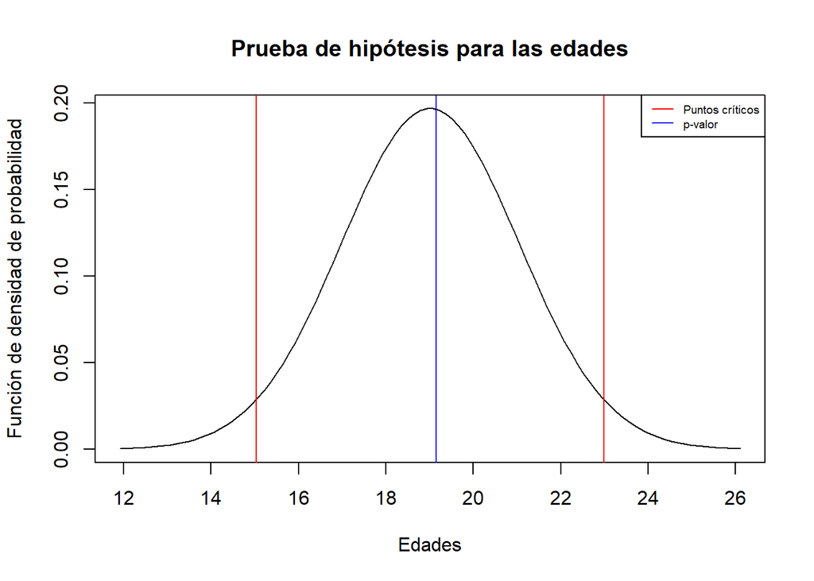

```r
#grafica
dum <- seq(-3.5,3.5,length=100)*sd_edad +x_edad
plot(dum,dnorm(dum,x_edad,sd_edad),type='l', xlab="Edades", ylab="Función de densidad de probabilidad", main = "Prueba de hipótesis para las edades")
legend("topright",95, legend = c("Puntos críticos", "p-valor"),col=c("red","blue"),lty=1:1, cex=0.6,)
abline(v=zcrit1, col="red") ##Punto crítico
abline(v=zcrit2, col="red") ##Punto crítico
abline(v=zobs_edad, col="blue") ##Punto asociado al p-valor
```

```r
#No se rechaza
```

$19.15 (valor-p) > 15.03 (punto\ crítico)$ $19.15 (valor-p) < 22.98 (punto\ crítico)$

Tal y como se pudo apreciar en el gráfico mostrado y por los resultados obtenidos, hemos concluido que la hipótesis nula; es decir, “los estudiantes de UTEC, que han cursado por lo menos un ciclo completo, tienen en promedio 19 años” no será rechazada.

## 5.2 Prueba de hipótesis unilateral de cola a la derecha:

Para esta prueba de hipótesis, lo que se busca es plantear si los estudiantes que han reprobado al menos un curso realizan poca cantidad de ejercicio físico (en concreto, menos de 2 horas a la semana). Para ello se plantea la siguiente hipótesis nula y la alternativa correspondientes.Se utilizará el valor de 2 horas para la hipótesis al ser el valor promedio de horas de deporte de toda la muestra.

Hipótesis nula: Los estudiantes que han reprobado al menos un curso realizan dos horas de ejercicio a la semana o menos.

$H_o: µ < 2$

Hipótesis alternativa: Los estudiantes que han reprobado al menos un curso realizan más de dos horas de ejercicio a la semana

$H_1: µ >= 2$

A continuación, se procede a realizar los cálculos pertinentes y a graficar la distribución normal en los valores de la variable donde las líneas rojas representan los puntos críticos y la azul representa en valor asociado a p-value. En este caso, al ser una prueba de hipótesis unilateral de cola a la derecha, la zona de rechazo está representada desde el punto crítico hacia la derecha de la distribución.

```r
#cantidad total de la muestra a estudiar.Para este caso, se filtra los que sí han jalado cursos.
UTECD <-  UTEC2 %>% filter(J_curso == "Si" )
q_deporte <- nrow(UTECD)

#desviación estándar de la muestra
sd_deporte <- sd(UTECD$Horas_Deporte, na.rm= TRUE)

#Media de cursos desprobados de la muestra
x_deporte <-mean(UTECD$Horas_Deporte, na.rm=1)

#media hipotética de la muestra
u_deporte = round(mean(UTEC2$Horas_Deporte, na.rm=1),0)
u_deporte
```

```
## [1] 2
```

```r
#Zobs
zobs_deporte= ((x_deporte-u_deporte)/(sd_deporte/sqrt(q_deporte)))*sd_deporte+x_deporte
zobs_deporte
```

```
## [1] 1.597872
```

```r
#zcrit
alpha=0.05
zcrit <- qnorm(alpha,mean=x_deporte,sd=sd_deporte,lower.tail = F)
zcrit
```

```
## [1] 5.758223
```

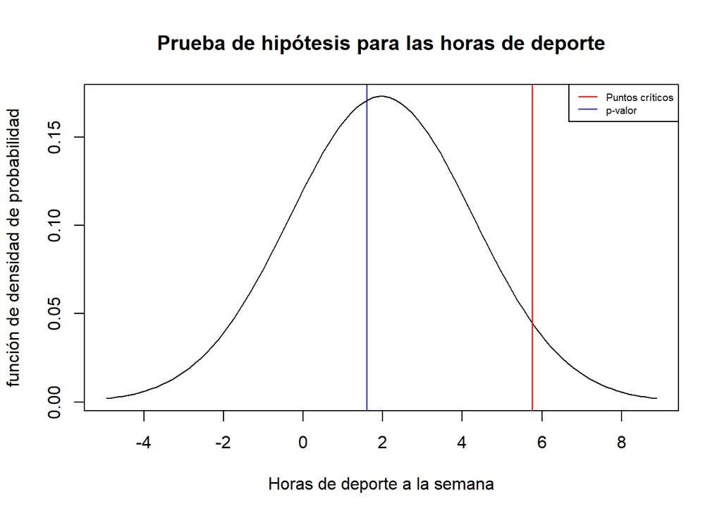

```r
#grafica
dum <- seq(-3,3,length=100)*sd_deporte +x_deporte
plot(dum,dnorm(dum,x_deporte,sd_deporte),type='l', xlab="Horas de deporte a la semana", ylab='función de densidad de probabilidad', main = "Prueba de hipótesis para las horas de deporte")
legend("topright",95, legend = c("Puntos críticos", "p-valor"),col=c("red","blue"),lty=1:1, cex=0.6,)
abline(v=zcrit, col="red") ##Punto crítico
abline(v=zobs_deporte, col="blue") ##Punto asociado al p-valor
```

$1.59 (valor-p) < 5.76 (punto \ crítico)$

Una vez apreciados los resultados y gráficos obtenidos para esta prueba de hipótesis, se puede determinar que la hipótesis nula no puede ser rechazada debido a que encaja dentro del rango establecido para los parámetros acordados; dando a entender que los estudiantes que han reprobado al menos un curso, realizan dos horas de ejercicio a la semana o menos.